# Econ294 Final Exam Report

Naihao Guo

2016/03/16

**Starting**

```r
library(dplyr)
library(ggplot2)
library(nycflights13)
my_db <- src_sqlite("db.sqlite11", create = T)
flights_sqlite <- copy_to(my_db, flights, temporary = FALSE, indexes = list(
  c("year", "month", "day"), "carrier", "tailnum"))
```

**a) weather**

```r
my_db2 <- src_sqlite("db.sqlite12", create = T)
weather_sqlite <- copy_to(my_db2, weather, temporary = FALSE, indexes = list(
  c("year", "month", "day"), "origin"))
flights_delay <- tbl(my_db, sql(
  "SELECT * FROM flights"))%>% collect()%>% mutate(canceled=is.na(arr_time))
weather <- tbl(my_db2, sql("SELECT * FROM weather"))%>% collect()
weather_delay_cancel <- inner_join(flights_delay,weather)
weather_delay_cancel <- as.data.frame(weather_delay_cancel)

weather.dep.fit <- lm(dep_delay ~ temp +  humid + wind_speed + visib,
                      data = weather_delay_cancel)
summary(weather.dep.fit)
```

```
##
## Call:
## lm(formula = dep_delay ~ temp + humid + wind_speed + visib, data = weather_delay_cancel)
##
## Residuals:
##     Min      1Q  Median      3Q     Max
##  -92.46  -18.96  -13.04    0.33 1115.74
##
## Coefficients:
##              Estimate Std. Error t value Pr(>|t|)
## (Intercept) 39.366604   0.983343   40.03   <2e-16 ***
## temp         0.207592   0.006526   31.81   <2e-16 ***
## humid       -0.130023   0.007023  -18.52   <2e-16 ***
## wind_speed   0.073233   0.006772   10.81   <2e-16 ***
## visib       -3.077103   0.067806  -45.38   <2e-16 ***
## ---
## Signif. codes:  0 '***' 0.001 '**' 0.01 '*' 0.05 '.' 0.1 ' ' 1
##
## Residual standard error: 40.83 on 117227 degrees of freedom
##   (19 observations deleted due to missingness)
## Multiple R-squared:  0.02462,    Adjusted R-squared:  0.02459
## F-statistic: 739.8 on 4 and 117227 DF,  p-value: < 2.2e-16
```

```r
weather.cancel.fit <- glm(
  canceled ~ temp +  humid + wind_speed + visib,
  data = weather_delay_cancel, family = binomial(link="logit"))
summary(weather.cancel.fit)
```

```
##
## Call:
## glm(formula = canceled ~ temp + humid + wind_speed + visib, family = binomial(link = "logit"),
##     data = weather_delay_cancel)
##
## Deviance Residuals:
##     Min       1Q   Median       3Q      Max
## -0.1088  -0.0583  -0.0469  -0.0364   3.9817
##
## Coefficients:
##              Estimate Std. Error z value Pr(>|z|)
## (Intercept) -6.983851   0.663473 -10.526  < 2e-16 ***
## temp         0.031013   0.004852   6.392 1.64e-10 ***
## humid       -0.005838   0.004859  -1.202  0.22954
## wind_speed   0.001644   0.003007   0.547  0.58452
## visib       -0.132682   0.040637  -3.265  0.00109 **
## ---
## Signif. codes:  0 '***' 0.001 '**' 0.01 '*' 0.05 '.' 0.1 ' ' 1
##
## (Dispersion parameter for binomial family taken to be 1)
##
##     Null deviance: 2311.5  on 117231  degrees of freedom
## Residual deviance: 2261.3  on 117227  degrees of freedom
##   (19 observations deleted due to missingness)
## AIC: 2271.3
##
## Number of Fisher Scoring iterations: 10
```

Temparture and visibility significantly effect cancelations.

**b) time of day, day of week, and time of year, and any other aspect of time**

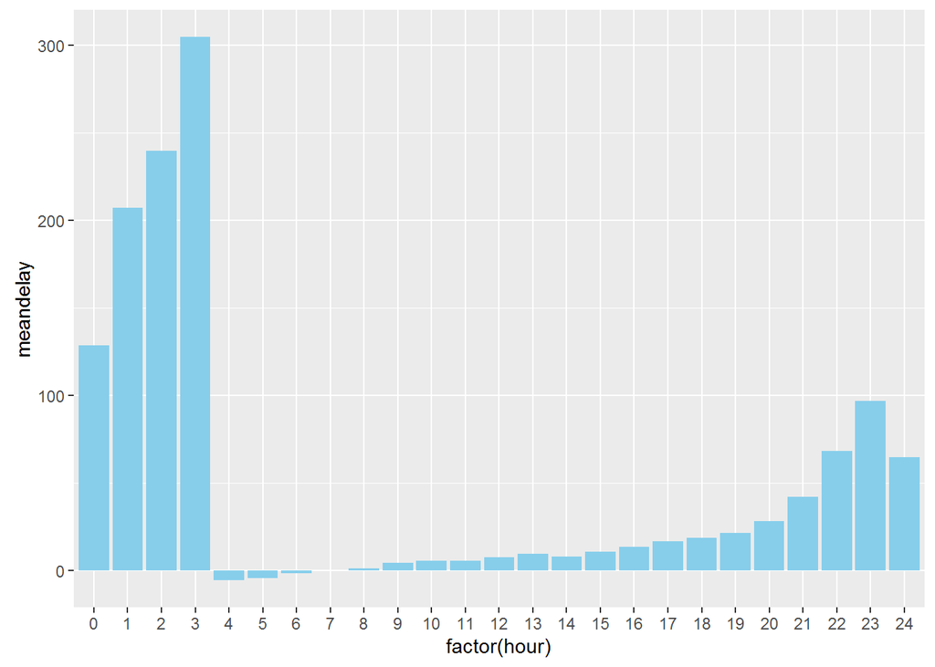

```r
flights_delay2 <- tbl(my_db, sql("SELECT * FROM flights"))%>% mutate(canceled = is.na(arr_time))
flights_delay2 <- as.data.frame(flights_delay)
flights_delay_df <- tapply(flights_delay2$dep_delay,flights_delay2$hour, mean, na.rm=T )
flights_delay_df2 <- data.frame(hour=0:24, meandelay=flights_delay_df)
fig <- ggplot(flights_delay_df2 , aes(
  x= factor(hour),y=meandelay)) + geom_bar(stat="identity", fill ="skyblue")
fig
```

```r
time.dep.fit.hour <- lm(dep_delay ~ hour,data = flights_delay)
summary(time.dep.fit.hour)
```

```
##
## Call:
## lm(formula = dep_delay ~ hour, data = flights_delay)
##
## Residuals:
##     Min      1Q  Median      3Q     Max
##  -70.32  -18.57   -8.02    1.13 1303.79
##
## Coefficients:
##              Estimate Std. Error t value Pr(>|t|)
## (Intercept) -15.69322    0.19441  -80.72   <2e-16 ***
## hour          2.15070    0.01383  155.47   <2e-16 ***
## ---
## Signif. codes:  0 '***' 0.001 '**' 0.01 '*' 0.05 '.' 0.1 ' ' 1
##
## Residual standard error: 38.81 on 328519 degrees of freedom
##   (8255 observations deleted due to missingness)
## Multiple R-squared:  0.06853,    Adjusted R-squared:  0.06853
## F-statistic: 2.417e+04 on 1 and 328519 DF,  p-value: < 2.2e-16
```

From the mean value departure delay and hours barplot, it can be seen hour seems to be a significant factor, and hour 3 has a most high average departure delay time.

```r
time.cancel.fit.hour <- glm(canceled ~ as.factor(hour), data = flights_delay, family = binomial(link ="logit"))
summary(time.cancel.fit.hour)
```

```
##
## Call:
## glm(formula = canceled ~ as.factor(hour), family = binomial(link = "logit"),
##     data = flights_delay)
##
## Deviance Residuals:
##     Min       1Q   Median       3Q      Max
## -0.1342  -0.0601  -0.0470  -0.0398   3.8594
##
## Coefficients:
##                     Estimate Std. Error z value Pr(>|z|)
## (Intercept)       -1.857e+01  2.198e+02  -0.084    0.933
## as.factor(hour)1   1.386e+01  2.198e+02   0.063    0.950
## as.factor(hour)2  -3.953e-11  8.444e+02   0.000    1.000
## as.factor(hour)3  -3.782e-11  1.979e+03   0.000    1.000
## as.factor(hour)4  -3.978e-11  4.333e+02   0.000    1.000
## as.factor(hour)5   1.176e+01  2.198e+02   0.054    0.957
## as.factor(hour)6   1.143e+01  2.198e+02   0.052    0.959
## as.factor(hour)7   1.137e+01  2.198e+02   0.052    0.959
## as.factor(hour)8   1.152e+01  2.198e+02   0.052    0.958
## as.factor(hour)9   1.112e+01  2.198e+02   0.051    0.960
## as.factor(hour)10  1.152e+01  2.198e+02   0.052    0.958
## as.factor(hour)11  1.173e+01  2.198e+02   0.053    0.957
## as.factor(hour)12  1.159e+01  2.198e+02   0.053    0.958
## as.factor(hour)13  1.140e+01  2.198e+02   0.052    0.959
## as.factor(hour)14  1.194e+01  2.198e+02   0.054    0.957
## as.factor(hour)15  1.269e+01  2.198e+02   0.058    0.954
## as.factor(hour)16  1.202e+01  2.198e+02   0.055    0.956
## as.factor(hour)17  1.225e+01  2.198e+02   0.056    0.956
## as.factor(hour)18  1.228e+01  2.198e+02   0.056    0.955
## as.factor(hour)19  1.222e+01  2.198e+02   0.056    0.956
## as.factor(hour)20  1.240e+01  2.198e+02   0.056    0.955
## as.factor(hour)21  1.256e+01  2.198e+02   0.057    0.954
## as.factor(hour)22  1.290e+01  2.198e+02   0.059    0.953
## as.factor(hour)23  1.139e+01  2.198e+02   0.052    0.959
## as.factor(hour)24 -4.014e-11  1.231e+03   0.000    1.000
##
## (Dispersion parameter for binomial family taken to be 1)
##
##     Null deviance: 6938.5  on 328520  degrees of freedom
## Residual deviance: 6827.1  on 328496  degrees of freedom
##   (8255 observations deleted due to missingness)
## AIC: 6877.1
##
## Number of Fisher Scoring iterations: 17
```

So now we can see the p value of hour, so it is not a significant factor effect cancelations.

```r
time.dep.fit.month <- lm(dep_delay ~ month,data = flights_delay)
summary(time.dep.fit.month)
```

```
##
## Call:
## lm(formula = dep_delay ~ month, data = flights_delay)
##
## Residuals:
##     Min      1Q  Median      3Q     Max
##  -54.35  -17.72  -14.06   -1.83 1287.05
##
## Coefficients:
##             Estimate Std. Error t value Pr(>|t|)
## (Intercept) 14.19045    0.15207   93.32   <2e-16 ***
## month       -0.23634    0.02055  -11.50   <2e-16 ***
## ---
## Signif. codes:  0 '***' 0.001 '**' 0.01 '*' 0.05 '.' 0.1 ' ' 1
##
## Residual standard error: 40.2 on 328519 degrees of freedom
##   (8255 observations deleted due to missingness)
## Multiple R-squared:  0.0004023,  Adjusted R-squared:  0.0003992
## F-statistic: 132.2 on 1 and 328519 DF,  p-value: < 2.2e-16
```

We can see that the p value of month is close to 0, so the month is significant factor effect departure delay, and one additional month is associated with -0.23634 minuses increase in departure delay.

```r
time.cancel.fit.month <- glm(canceled ~ as.factor(month),
                             data = flights_delay, family = binomial(link ="logit"))
summary(time.cancel.fit.month)
```

```
##
## Call:
## glm(formula = canceled ~ as.factor(month), family = binomial(link = "logit"),
##     data = flights_delay)
##
## Deviance Residuals:
##     Min       1Q   Median       3Q      Max
## -0.3260  -0.2687  -0.2054  -0.1866   3.0860
##
## Coefficients:
##                    Estimate Std. Error z value Pr(>|z|)
## (Intercept)        -3.89956    0.04363 -89.381  < 2e-16 ***
## as.factor(month)2   0.99119    0.05216  19.004  < 2e-16 ***
## as.factor(month)3   0.45398    0.05533   8.205 2.31e-16 ***
## as.factor(month)4   0.23853    0.05786   4.122 3.75e-05 ***
## as.factor(month)5   0.05125    0.06002   0.854   0.3932
## as.factor(month)6   0.66693    0.05360  12.442  < 2e-16 ***
## as.factor(month)7   0.59590    0.05383  11.071  < 2e-16 ***
## as.factor(month)8  -0.14277    0.06257  -2.282   0.0225 *
## as.factor(month)9  -0.08405    0.06265  -1.342   0.1797
## as.factor(month)10 -0.85368    0.07737 -11.033  < 2e-16 ***
## as.factor(month)11 -0.77120    0.07677 -10.046  < 2e-16 ***
## as.factor(month)12  0.65823    0.05371  12.256  < 2e-16 ***
## ---
## Signif. codes:  0 '***' 0.001 '**' 0.01 '*' 0.05 '.' 0.1 ' ' 1
##
## (Dispersion parameter for binomial family taken to be 1)
##
##     Null deviance: 80884  on 336775  degrees of freedom
## Residual deviance: 78867  on 336764  degrees of freedom
## AIC: 78891
##
## Number of Fisher Scoring iterations: 7
```

So now we can see that Feb, Mar, Apr, June, July, and Dec significantly affect the cancelation with a positive influence, while Oct and Nov have negative influence on cancelation.

```r
flights_delay$quarter <- ifelse(flights_delay$month %in% c(1,2,3),1, ifelse(
  flights_delay$month %in% c(4,5,6),2, ifelse(flights_delay$month %in% c(7,8,9),3,4)))

time.dep.fit.quarter <- lm(dep_delay ~ quarter,data = flights_delay)
summary(time.dep.fit.quarter)
```

```
##
## Call:
## lm(formula = dep_delay ~ quarter, data = flights_delay)
##
## Residuals:
##     Min      1Q  Median      3Q     Max
##  -54.36  -17.96  -14.09   -1.96 1287.04
##
## Coefficients:
##             Estimate Std. Error t value Pr(>|t|)
## (Intercept) 14.82110    0.17434   85.01   <2e-16 ***
## quarter     -0.86477    0.06326  -13.67   <2e-16 ***
## ---
## Signif. codes:  0 '***' 0.001 '**' 0.01 '*' 0.05 '.' 0.1 ' ' 1
##
## Residual standard error: 40.2 on 328519 degrees of freedom
##   (8255 observations deleted due to missingness)
## Multiple R-squared:  0.0005686,  Adjusted R-squared:  0.0005655
## F-statistic: 186.9 on 1 and 328519 DF,  p-value: < 2.2e-16
```

We can see that the p value of quarter is 2e-16 < 0.05, so the quarter is significant factor effect departure delay, and one additional quarter is associated with -0.86477 minuses increase in departure delay.

```r
time.cancel.fit.quarter <- glm(canceled ~ as.factor(quarter),
                               data = flights_delay, family = binomial(link = "logit"))
summary(time.cancel.fit.quarter )
```

```
##
## Call:
## glm(formula = canceled ~ as.factor(quarter), family = binomial(link = "logit"),
##     data = flights_delay)
##
## Deviance Residuals:
##     Min       1Q   Median       3Q      Max
## -0.2616  -0.2379  -0.2194  -0.1932   2.8250
##
## Coefficients:
##                     Estimate Std. Error  z value Pr(>|z|)
## (Intercept)         -3.35772    0.01951 -172.083  < 2e-16 ***
## as.factor(quarter)2 -0.19259    0.02850   -6.757 1.41e-11 ***
## as.factor(quarter)3 -0.35704    0.02966  -12.038  < 2e-16 ***
## as.factor(quarter)4 -0.61385    0.03216  -19.089  < 2e-16 ***
## ---
## Signif. codes:  0 '***' 0.001 '**' 0.01 '*' 0.05 '.' 0.1 ' ' 1
##
## (Dispersion parameter for binomial family taken to be 1)
##
##     Null deviance: 80884  on 336775  degrees of freedom
## Residual deviance: 80476  on 336772  degrees of freedom
## AIC: 80484
##
## Number of Fisher Scoring iterations: 6
```

Here we can see that the p value of quarters are small, so they are significant factors affect cancelations.

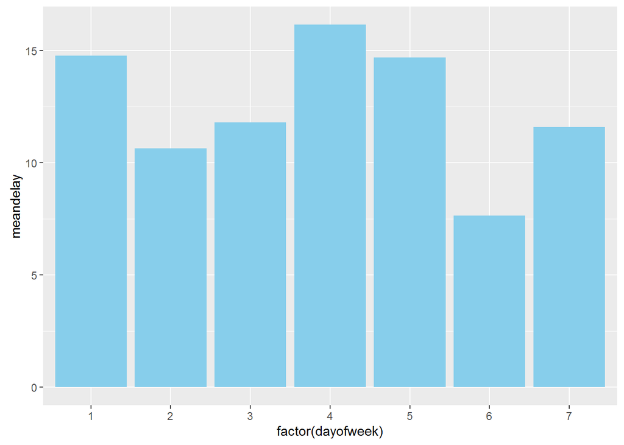

```r
months <- ifelse(flights_delay$month < 10, paste0("0",flights_delay$month),flights_delay$month)
days <- ifelse(flights_delay$day < 10, paste0("0",flights_delay$day),flights_delay$day)
flights_delay$dayofweek <- strftime(as.Date(paste0(flights_delay$year,"-",months,"-",days)),"%u")
flights_delay_df <- tapply(flights_delay$dep_delay,flights_delay$dayofweek, mean, na.rm=T )
flights_delay_df2 <- data.frame(dayofweek=1:7, meandelay=flights_delay_df)
fig <- ggplot(flights_delay_df2 , aes(
  x= factor(dayofweek),y=meandelay)) + geom_bar(stat="identity", fill = "skyblue")
fig
```

```r
time.dep.fit.dayofweek <- lm(dep_delay ~ as.integer(dayofweek),data = flights_delay)
summary(time.dep.fit.dayofweek)
```

```
##
## Call:
## lm(formula = dep_delay ~ as.integer(dayofweek), data = flights_delay)
##
## Residuals:
##     Min      1Q  Median      3Q     Max
##  -54.83  -17.60  -14.21   -1.83 1288.02
##
## Coefficients:
##                       Estimate Std. Error t value Pr(>|t|)
## (Intercept)           14.14131    0.15429   91.66   <2e-16 ***
## as.integer(dayofweek) -0.38563    0.03528  -10.93   <2e-16 ***
## ---
## Signif. codes:  0 '***' 0.001 '**' 0.01 '*' 0.05 '.' 0.1 ' ' 1
##
## Residual standard error: 40.2 on 328519 degrees of freedom
##   (8255 observations deleted due to missingness)
## Multiple R-squared:  0.0003636,  Adjusted R-squared:  0.0003606
## F-statistic: 119.5 on 1 and 328519 DF,  p-value: < 2.2e-16
```

From the mean value departure delay and day of week barplot, it can be seen day of week seems to be a significant factor, and day of week 4 has a most high average departure delay time while day of week 6 has a most low average departure delay time.

From the model output, We can see that the p value of dayofweek is less than 0.05, so the dayofweek is a significant factor effect departure delay.

```r
time.cancel.fit.dayofweek <- glm(canceled ~ as.integer(dayofweek),
                                 data = flights_delay, family = binomial(link = "logit"))
summary(time.cancel.fit.dayofweek)
```

```
##
## Call:
## glm(formula = canceled ~ as.integer(dayofweek), family = binomial(link = "logit"),
##     data = flights_delay)
##
## Deviance Residuals:
##     Min       1Q   Median       3Q      Max
## -0.2389  -0.2353  -0.2284  -0.2217   2.7379
##
## Coefficients:
##                        Estimate Std. Error z value Pr(>|z|)
## (Intercept)           -3.512182   0.023412 -150.02  < 2e-16 ***
## as.integer(dayofweek) -0.030293   0.005488   -5.52 3.39e-08 ***
## ---
## Signif. codes:  0 '***' 0.001 '**' 0.01 '*' 0.05 '.' 0.1 ' ' 1
##
## (Dispersion parameter for binomial family taken to be 1)
##
##     Null deviance: 80884  on 336775  degrees of freedom
## Residual deviance: 80853  on 336774  degrees of freedom
## AIC: 80857
##
## Number of Fisher Scoring iterations: 6
```

Here we can see that the p value of dayofweek is 3.39e-8 < 0.05, so it is a significant factor effect cancelations.

**c) airport destination**

```r
flights_delay <- tbl(my_db, sql("SELECT dep_delay,arr_time, year, dest FROM flights")
                     ) %>% filter(year == 2013) %>% mutate(canceled = is.na(arr_time))
flights_delay <- as.data.frame(flights_delay)
dest.dep.fit <- lm(dep_delay ~ dest, data= flights_delay)
summary(dest.dep.fit)
```

```
##
## Call:
## lm(formula = dep_delay ~ dest, data = flights_delay)
##
## Residuals:
##     Min      1Q  Median      3Q     Max
##  -53.33  -13.74   -9.72   -1.72 1284.98
##
## Coefficients:
##              Estimate Std. Error t value Pr(>|t|)
## (Intercept)   8.22785    3.82165   2.153 0.031325 *
## destACK      -8.57567    8.04799  -1.066 0.286622
## destALB      23.73511    4.81162   4.933 8.12e-07 ***
## destATL      -0.78190    3.85148  -0.203 0.839124
## destAUS      -0.93959    4.03973  -0.233 0.816083
## destAVL       1.88483    5.55479   0.339 0.734373
## destBDL      11.23694    5.55479   2.023 0.043083 *
## destBGR       8.58296    4.73296   1.813 0.069766 .
## destBHM      18.43882    5.53444   3.332 0.000864 ***
## destBNA       3.51403    3.90385   0.900 0.368045
## destBOS      -3.05842    3.85490  -0.793 0.427556
## destBQN      -3.43210    4.41756  -0.777 0.437206
## destBTV      -1.88463    4.02923  -0.468 0.639972
## destBUF       2.10850    3.92515   0.537 0.591148
## destBUR      -4.49509    4.95495  -0.907 0.364308
## destBWI       6.26503    4.08143   1.535 0.124784
## destBZN      -0.22785   17.40845  -0.013 0.989557
## destCAE      31.32388    7.37503   4.247 2.17e-05 ***
## destCAK       8.34153    4.48615   1.859 0.062974 .
## destCHS       2.92688    4.01005   0.730 0.465460
## destCLE      -0.76697    3.93800  -0.195 0.845580
## destCLT      -1.71129    3.85770  -0.444 0.657329
## destCMH       0.12092    3.96759   0.030 0.975687
## destCRW       2.36474    7.57220   0.312 0.754819
## destCVG       5.75258    3.95367   1.455 0.145674
## destDAY       9.35416    4.20207   2.226 0.026011 *
## destDCA      -1.63634    3.87651  -0.422 0.672941
## destDEN       2.09758    3.89260   0.539 0.589983
## destDFW      -2.88186    3.88149  -0.742 0.457809
## destDSM      11.12853    4.55436   2.443 0.014548 *
```

[output cut: 63 more lines]

```
## destSRQ      -2.99356    4.23103  -0.708 0.479241
## destSTL       5.55841    3.93401   1.413 0.157686
## destSTT      -4.31055    4.82495  -0.893 0.371652
## destSYR       4.72867    4.09709   1.154 0.248439
## destTPA      -2.47135    3.88876  -0.636 0.525097
## destTUL      23.04688    5.22342   4.412 1.02e-05 ***
## destTYS      13.86505    4.57274   3.032 0.002429 **
## destXNA      -5.45082    4.30151  -1.267 0.205091
## ---
## Signif. codes:  0 '***' 0.001 '**' 0.01 '*' 0.05 '.' 0.1 ' ' 1
##
## Residual standard error: 33.97 on 98005 degrees of freedom
##   (1894 observations deleted due to missingness)
## Multiple R-squared:  0.01215,    Adjusted R-squared:  0.01115
## F-statistic: 12.06 on 100 and 98005 DF,  p-value: < 2.2e-16
```

From the plot, it can be easily seen that some destinations have large average departure delay, and there is one destination seems has the most early average departure time.

From the above model ouput, there are some destinations would significantly effect departure delays, for example, dest ALB has p values less than 0.05, so th destination is significant factor, and the estimated value is 23.73511, so it means it is about departure delay 23.73511 minutes more than the base line destination.

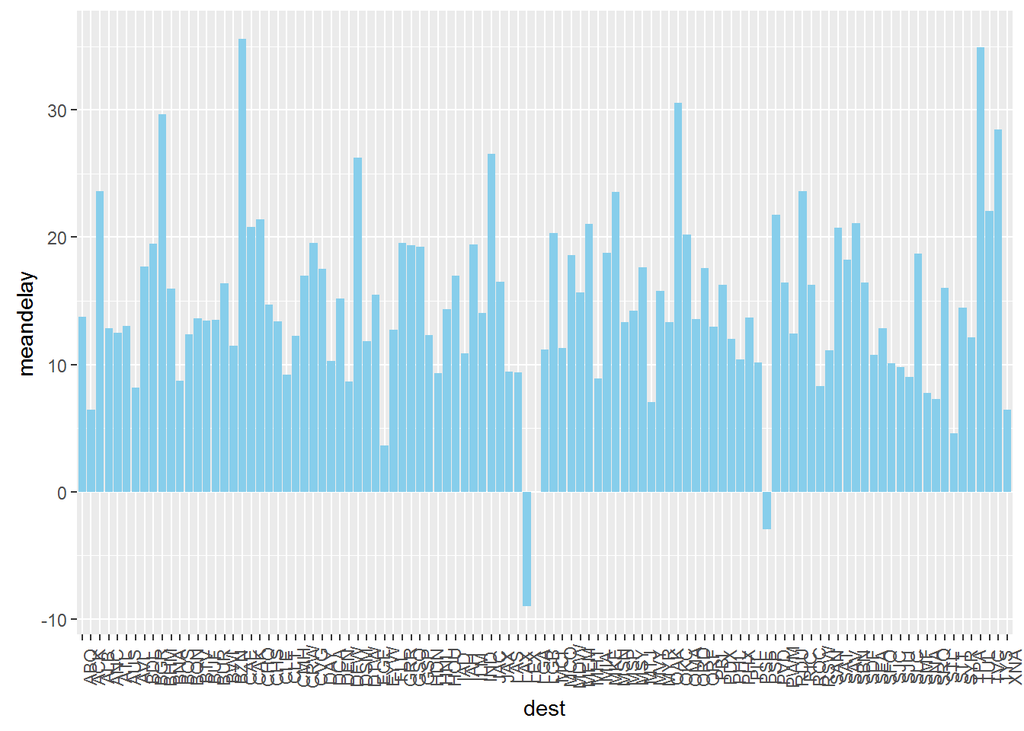

```r
tmp <- group_by(flights, dest) %>% summarise(meandelay = mean(dep_delay,na.rm=TRUE))
tmp <- as.data.frame(tmp)
fig <- ggplot(tmp, aes(x= dest,y=meandelay)) + geom_bar(stat="identity",fill ="skyblue") + theme(axis.text.x=element_text(angle = 90))
fig
```

```r
dest.cancel.fit <- glm(canceled ~ dest, data= flights_delay, family = binomial(link = "logit"))
summary(dest.cancel.fit )
```

```
##
## Call:
## glm(formula = canceled ~ dest, family = binomial(link = "logit"),
##     data = flights_delay)
##
## Deviance Residuals:
##     Min       1Q   Median       3Q      Max
## -0.4621  -0.2255  -0.1673  -0.1013   3.4558
##
## Coefficients:
##               Estimate Std. Error z value Pr(>|z|)
## (Intercept) -1.857e+01  7.339e+02  -0.025    0.980
## destACK     -1.893e-10  1.545e+03   0.000    1.000
## destALB      1.586e+01  7.339e+02   0.022    0.983
## destATL      1.430e+01  7.339e+02   0.019    0.984
## destAUS      1.385e+01  7.339e+02   0.019    0.985
## destAVL      1.638e+01  7.339e+02   0.022    0.982
## destBDL      1.625e+01  7.339e+02   0.022    0.982
## destBGR      1.468e+01  7.339e+02   0.020    0.984
## destBHM      1.568e+01  7.339e+02   0.021    0.983
## destBNA      1.514e+01  7.339e+02   0.021    0.984
## destBOS      1.490e+01  7.339e+02   0.020    0.984
## destBQN     -1.873e-10  8.483e+02   0.000    1.000
## destBTV      1.449e+01  7.339e+02   0.020    0.984
## destBUF      1.447e+01  7.339e+02   0.020    0.984
## destBUR     -1.888e-10  9.515e+02   0.000    1.000
## destBWI      1.480e+01  7.339e+02   0.020    0.984
## destBZN     -1.869e-10  3.343e+03   0.000    1.000
## destCAE      1.633e+01  7.339e+02   0.022    0.982
## destCAK     -1.879e-10  8.615e+02   0.000    1.000
## destCHS      1.474e+01  7.339e+02   0.020    0.984
## destCLE      1.500e+01  7.339e+02   0.020    0.984
## destCLT      1.471e+01  7.339e+02   0.020    0.984
## destCMH      1.551e+01  7.339e+02   0.021    0.983
## destCRW     -1.880e-10  1.454e+03   0.000    1.000
## destCVG      1.537e+01  7.339e+02   0.021    0.983
## destDAY      1.589e+01  7.339e+02   0.022    0.983
## destDCA      1.552e+01  7.339e+02   0.021    0.983
## destDEN      1.286e+01  7.339e+02   0.018    0.986
## destDFW      1.555e+01  7.339e+02   0.021    0.983
```

[output cut: 65 more lines]

```
## destSTL      1.531e+01  7.339e+02   0.021    0.983
## destSTT      1.368e+01  7.339e+02   0.019    0.985
## destSYR      1.513e+01  7.339e+02   0.021    0.984
## destTPA      1.325e+01  7.339e+02   0.018    0.986
## destTUL      1.568e+01  7.339e+02   0.021    0.983
## destTYS      1.584e+01  7.339e+02   0.022    0.983
## destXNA      1.449e+01  7.339e+02   0.020    0.984
##
## (Dispersion parameter for binomial family taken to be 1)
##
##     Null deviance: 19327  on 99999  degrees of freedom
## Residual deviance: 18077  on 99899  degrees of freedom
## AIC: 18279
##
## Number of Fisher Scoring iterations: 17
```

So from the output, all the p values are greater than 0.05, we can consider there is no significant of destination effect on cancelations.

**d) characteristics of the plane**

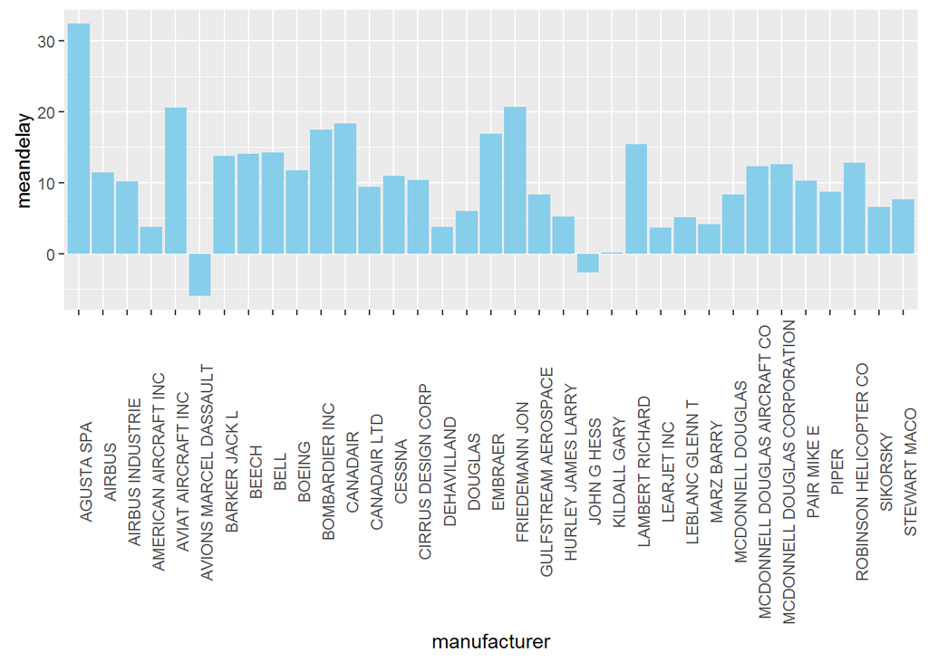

```r
flights_delay <- tbl(my_db, sql("SELECT dep_delay,arr_time, year,tailnum FROM flights")
                     )%>%filter(year == 2013) %>% mutate(canceled = is.na(arr_time))
flights_delay <- flights_delay %>% left_join(planes, by = "tailnum", copy = TRUE)
tmp<- group_by(flights_delay, manufacturer) %>% summarise(meandelay = mean(dep_delay))
tmp <- as.data.frame(tmp)
fig <- ggplot(tmp, aes(x= manufacturer,y=meandelay)) + geom_bar(
  stat="identity",fill ="skyblue") + theme(axis.text.x=element_text(angle = 90))
fig
```

```r
flights_delay <- as.data.frame(flights_delay)
plane.dep.fit <- lm(dep_delay ~  type + manufacturer + engines + engine, data= flights_delay)
summary(plane.dep.fit)
```

```
##
## Call:
## lm(formula = dep_delay ~ type + manufacturer + engines + engine,
##     data = flights_delay)
##
## Residuals:
##     Min      1Q  Median      3Q     Max
##  -50.27  -14.37   -9.71   -1.37 1294.86
##
## Coefficients: (3 not defined because of singularities)
##                                           Estimate Std. Error t value
## (Intercept)                                -0.1022    24.9188  -0.004
## typeFixed wing single engine                3.3318    12.4916   0.267
## typeRotorcraft                             11.7793    19.8812   0.592
## manufacturerAIRBUS                         -5.3792    18.0230  -0.298
## manufacturerAIRBUS INDUSTRIE               -4.9548    18.0235  -0.275
## manufacturerAMERICAN AIRCRAFT INC           3.8750    14.8879   0.260
## manufacturerAVIAT AIRCRAFT INC              1.1806    16.7068   0.071
## manufacturerBARKER JACK L                  11.4393    12.8318   0.891
## manufacturerBEECH                           0.5315    20.8729   0.025
## manufacturerBELL                          -18.3130    13.7791  -1.329
## manufacturerBOEING                         -3.1990    18.0226  -0.177
## manufacturerBOMBARDIER INC                  3.0242    18.0244   0.168
## manufacturerCANADAIR                        6.7469    18.0949   0.373
## manufacturerCANADAIR LTD                  -22.9535    26.1182  -0.879
## manufacturerCESSNA                         10.0485    12.4848   0.805
## manufacturerCIRRUS DESIGN CORP             13.6250    12.6627   1.076
## manufacturerDEHAVILLAND                     7.3092    14.4909   0.504
## manufacturerDOUGLAS                       -12.7803    26.6486  -0.480
## manufacturerEMBRAER                         1.8490    18.0225   0.103
## manufacturerFRIEDEMANN JON                 11.2750    14.3831   0.784
## manufacturerGULFSTREAM AEROSPACE           -5.1395    18.5457  -0.277
## manufacturerHURLEY JAMES LARRY             -1.8750    27.1816  -0.069
## manufacturerKILDALL GARY                    5.6964    15.2383   0.374
## manufacturerLAMBERT RICHARD                32.2250    15.0525   2.141
## manufacturerLEARJET INC                   -10.1229    21.0466  -0.481
## manufacturerLEBLANC GLENN T                15.4250    16.3089   0.946
## manufacturerMARZ BARRY                      0.3523    15.9761   0.022
## manufacturerMCDONNELL DOUGLAS              -6.1524    18.0506  -0.341
## manufacturerMCDONNELL DOUGLAS AIRCRAFT CO  -5.2297    18.0338  -0.290
```

[output cut: 46 more lines]

```
## manufacturerSIKORSKY                        0.0203 *
## manufacturerSTEWART MACO                        NA
## engines                                     0.3113
## engineReciprocating                         0.0356 *
## engineTurbo-fan                             0.7131
## engineTurbo-jet                             0.6766
## engineTurbo-prop                                NA
## engineTurbo-shaft                               NA
## ---
## Signif. codes:  0 '***' 0.001 '**' 0.01 '*' 0.05 '.' 0.1 ' ' 1
##
## Residual standard error: 34.38 on 83585 degrees of freedom
##   (16377 observations deleted due to missingness)
## Multiple R-squared:  0.009727,   Adjusted R-squared:  0.009288
## F-statistic: 22.19 on 37 and 83585 DF,  p-value: < 2.2e-16
```

From the plot, it can be easily found, planes made by AGUSTA SPA manufacturer have the most high average departure delay time.

From the model ouput, manufacturer LAMBERT RICHARD and SIKORSKY has significant effect on departure delays as their p values are both less than 0.05, and we can find number of engines is not significant factor, but Reciprocating type engine has a pvalue less than 0.05 which is a significant factor, At last, type is also not a significant factor.

```r
plane.cancel.fit <- glm(canceled ~  type + manufacturer + engines + engine,
                        data= flights_delay, family = binomial(link = "logit"))
summary(plane.cancel.fit)
```

```
##
## Call:
## glm(formula = canceled ~ type + manufacturer + engines + engine,
##     family = binomial(link = "logit"), data = flights_delay)
##
## Deviance Residuals:
##     Min       1Q   Median       3Q      Max
## -0.9005  -0.1868  -0.1044  -0.0704   3.7875
##
## Coefficients: (3 not defined because of singularities)
##                                             Estimate Std. Error z value
## (Intercept)                               -5.033e+01  1.154e+03  -0.044
## typeFixed wing single engine               1.687e+01  5.814e+02   0.029
## typeRotorcraft                             2.755e+01  1.332e+03   0.021
## manufacturerAIRBUS                         2.514e+01  1.242e+03   0.020
## manufacturerAIRBUS INDUSTRIE               2.435e+01  1.242e+03   0.020
## manufacturerAMERICAN AIRCRAFT INC          1.379e+01  8.484e+02   0.016
## manufacturerAVIAT AIRCRAFT INC             2.049e-09  1.166e+03   0.000
## manufacturerBARKER JACK L                  2.049e-09  8.955e+02   0.000
## manufacturerBEECH                          2.755e+01  1.404e+03   0.020
## manufacturerBELL                           9.120e-01  8.692e+02   0.001
## manufacturerBOEING                         2.472e+01  1.242e+03   0.020
## manufacturerBOMBARDIER INC                 2.631e+01  1.242e+03   0.021
## manufacturerCANADAIR                       2.756e+01  1.242e+03   0.022
## manufacturerCANADAIR LTD                   2.263e+01  1.242e+03   0.018
## manufacturerCESSNA                         1.379e+01  8.484e+02   0.016
## manufacturerCIRRUS DESIGN CORP             2.049e-09  8.837e+02   0.000
## manufacturerDEHAVILLAND                    1.362e+01  8.484e+02   0.016
## manufacturerDOUGLAS                        7.538e+00  1.371e+03   0.005
## manufacturerEMBRAER                        2.692e+01  1.242e+03   0.022
## manufacturerFRIEDEMANN JON                 1.357e+01  8.484e+02   0.016
## manufacturerGULFSTREAM AEROSPACE           2.800e+01  1.242e+03   0.023
## manufacturerHURLEY JAMES LARRY             1.587e+01  8.484e+02   0.019
## manufacturerKILDALL GARY                   2.049e-09  1.063e+03   0.000
## manufacturerLAMBERT RICHARD                2.049e-09  1.051e+03   0.000
## manufacturerLEARJET INC                    1.379e+01  1.455e+03   0.009
## manufacturerLEBLANC GLENN T                2.049e-09  1.138e+03   0.000
## manufacturerMARZ BARRY                     2.049e-09  1.115e+03   0.000
## manufacturerMCDONNELL DOUGLAS              2.691e+01  1.242e+03   0.022
## manufacturerMCDONNELL DOUGLAS AIRCRAFT CO  2.413e+01  1.242e+03   0.019
```

[output cut: 50 more lines]

```
## engineTurbo-fan                              0.991
## engineTurbo-jet                              0.992
## engineTurbo-prop                                NA
## engineTurbo-shaft                               NA
## ---
## Signif. codes:  0 '***' 0.001 '**' 0.01 '*' 0.05 '.' 0.1 ' ' 1
##
## (Dispersion parameter for binomial family taken to be 1)
##
##     Null deviance: 10978.3  on 84575  degrees of freedom
## Residual deviance:  9891.7  on 84538  degrees of freedom
##   (15424 observations deleted due to missingness)
## AIC: 9967.7
##
## Number of Fisher Scoring iterations: 15
```

As from the output, we can see almost all of the factors are not significant factors with p values greater than 0.05, except engines has a very small p value, so it is a significant factor effect on cancelation.